# R Notebook

```r
library(wordbankr) # WB data
library(tidyverse) # tidy
library(mirt) # IRT models
library(ltm) #
library(difr) # some differential item functioning tools.
library(psych) # some psychometric stuff (tests of dimensionality)
library(Gifi)# some more psychometric stuff (tests of dimensionality)
library(knitr) # some formatting, tables, etc
library(patchwork) # combining plos.
```

```r
Inst <- get_instrument_data(language="English (American)", form="WS")
Admin <- get_administration_data(language="English (American)", form="WS")
Item <- get_item_data(language="English (American)", form = "WS")
```

```r
Complex <- Admin %>%
  full_join(.,Inst, by="data_id") %>%
  full_join(., Item, by="num_item_id") %>%
  filter(longitudinal==FALSE) %>%
  filter(type == "complexity") %>%
  mutate(
    out = ifelse(value=="complex", yes=1, no=0)
  )
```

Find NAs.

```r
Complex %>%
  filter(is.na(out)) %>%
  group_by(definition) %>%
  count() # looks like 1426 participants don't have item-level complexity scores.
```

| definition | n |
| --- | --- |
| baby blanket / baby's blanket | 1426 |
| baby crying / baby crying cuz she's sad | 1426 |
| baby crying / baby is crying | 1426 |
| baby want eat / baby want to eat | 1426 |
| coffee hot / that coffee hot | 1426 |
| cookie mommy / cookie for mommy | 1426 |
| daddy car / daddy's car | 1426 |
| daddy pick me up / daddy picked me up | 1426 |
| doggie kiss me / doggie kissed me | 1426 |
| doggie table / doggie on table | 1426 |

[output cut: 27 more lines]

```r
NA
```

Looks like there are 1426 participants don’t have item-level complexity scores. So let’s drop those.

```r
Complex <- filter(Complex, !is.na(out))
```

Let’s look at means and SDs for each item:

```r
Complex %>%
  group_by(definition) %>%
  summarise(
    mean=mean(out),
    sd=sd(out),
    category = first(complexity_category)
  ) %>%
  arrange(category) %>%
  kable(caption="Means and SDs for Each Item (Arranged by Item)")
```

Means and SDs for Each Item (Arranged by Item)

| definition | mean | sd | category |
| --- | --- | --- | --- |
| baby blanket / baby’s blanket | 0.3873745 | 0.4872378 | morphology |
| daddy car / daddy’s car | 0.4451220 | 0.4970684 | morphology |
| daddy pick me up / daddy picked me up | 0.1743185 | 0.3794512 | morphology |
| doggie kiss me / doggie kissed me | 0.1879484 | 0.3907410 | morphology |
| I fall down / I fell down | 0.1807747 | 0.3849005 | morphology |
| I make tower / I making tower | 0.2360115 | 0.4247055 | morphology |
| kitty go away / kitty went away | 0.1280488 | 0.3342041 | morphology |
| kitty sleep / kitty sleeping | 0.4192970 | 0.4935326 | morphology |
| more cookie / more cookies | 0.3758967 | 0.4844404 | morphology |
| these my tooth / these my teeth | 0.4533716 | 0.4979103 | morphology |
| two foot / two feet | 0.4214491 | 0.4938798 | morphology |
| two shoe / two shoes | 0.4422525 | 0.4967431 | morphology |
| baby crying / baby crying cuz she’s sad | 0.1599713 | 0.3666452 | syntax |
| baby crying / baby is crying | 0.1624821 | 0.3689586 | syntax |
| baby want eat / baby want to eat | 0.2650646 | 0.4414468 | syntax |
| coffee hot / that coffee hot | 0.1929699 | 0.3947004 | syntax |
| cookie mommy / cookie for mommy | 0.2413917 | 0.4280040 | syntax |
| doggie table / doggie on table | 0.3511478 | 0.4774147 | syntax |
| don’t read book / don’t want you read that book | 0.1818508 | 0.3857907 | syntax |
| go bye-bye / wanna go bye-bye | 0.2679340 | 0.4429625 | syntax |
| I like read stories / I like to read stories | 0.1779053 | 0.3825016 | syntax |
| I no do it / I can’t do it | 0.2482066 | 0.4320498 | syntax |
| I sing song / I sing song for you | 0.1449067 | 0.3520699 | syntax |
| I want that / I want that one you got | 0.1137016 | 0.3175054 | syntax |
| lookit / lookit what I got | 0.2410330 | 0.4277870 | syntax |
| lookit me / lookit me dancing | 0.2596844 | 0.4385400 | syntax |
| no wash dolly / don’t wash dolly | 0.2116212 | 0.4085310 | syntax |
| read me story Mommy / read me a story Mommy | 0.1635581 | 0.3699405 | syntax |
| that my truck / that’s my truck | 0.2822812 | 0.4501902 | syntax |
| there a kitty / there’s a kitty | 0.3210187 | 0.4669517 | syntax |
| turn on light / turn on light so I can see | 0.0961263 | 0.2948172 | syntax |
| want cookies / want cookies and milk | 0.2048063 | 0.4036324 | syntax |
| want more juice / want juice in there | 0.2051650 | 0.4038946 | syntax |
| we made this / me and Paul made this | 0.1603300 | 0.3669776 | syntax |
| where’s my dolly / where’s my dolly name Sam | 0.1093974 | 0.3121932 | syntax |
| where mommy go / where did mommy go | 0.1822095 | 0.3860863 | syntax |
| you fix it / can you fix it | 0.1025825 | 0.3034672 | syntax |

Let’s also check the distribution of means for each category

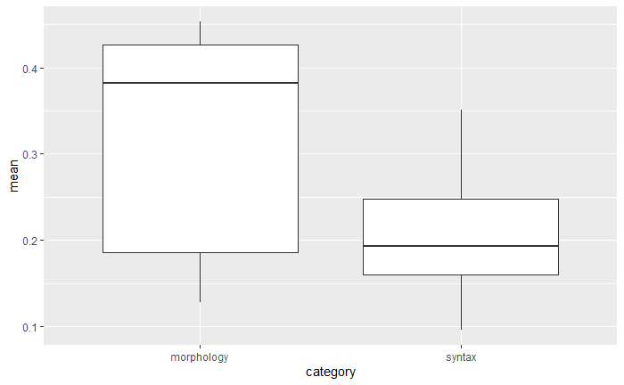

```r
Complex %>%
  group_by(definition) %>%
  summarise(
    mean=mean(out),
    category = first(complexity_category)
  ) %>%
  ggplot(aes(x=category, y= mean)) + geom_boxplot()
```

Prepare dataset for IRT modeling. I’m going to re-name each item to its category and its item number so as to make some graphs easier to read.

```r
Complex_short <- Complex %>%
  dplyr::select(data_id, value, complexity_category, num_item_id) %>%
  mutate(
    out = ifelse(value=="complex", yes=1, no=0),
    label = str_c(complexity_category, num_item_id)
  ) %>%
  dplyr::select(-value) %>%
  pivot_wider(id_cols=data_id, names_from = "label", values_from="out") %>%
  dplyr::select(-data_id)
```

Create polychoric correlation matrix. I created a vector with labels, for labeling of the correlation plot.

```r
Complex_poly <- polychoric(Complex_short)

rho <- Complex_poly$rho

lab = c("1", "2", "3", "4", "5", "6", "7", "8", "9", "10", "11", "12", "13", "14", "15", "16", "17", "18", "19", "20", "21", "22", "23", "24", "25", "26", "27", "28", "29", "30", "31", "32", "33", "34", "35", "36", "37") # create labels for corPlot because the defintions are long and take up a ton of space
```

Check out the correlations

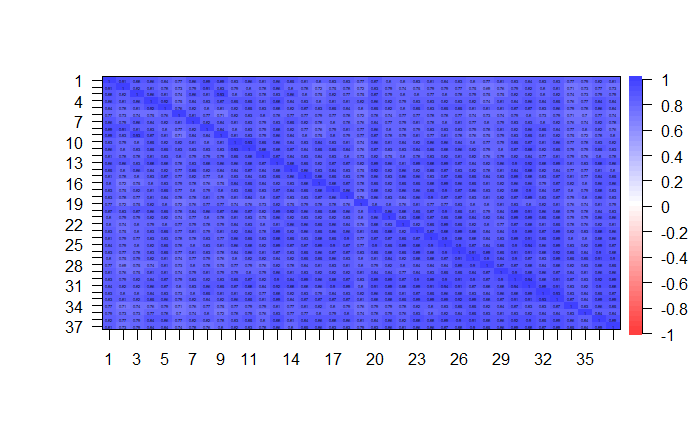

```r
corPlot(rho, labels=lab)
```

They look really high.

Let’s examine the dimensionality.

Princals is basically categorical pca.

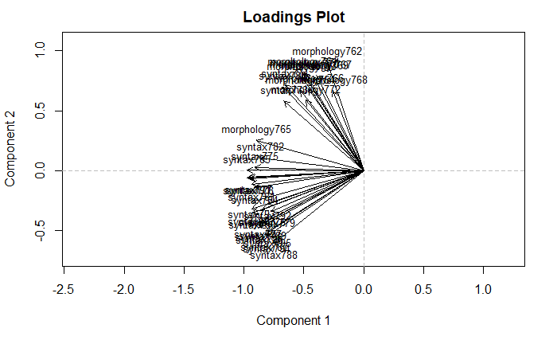

```r
pc <- princals(rho)

plot(pc)
```

Interesting. Seems like maybe there are 2 factor.

Scree plot with parallel analysis.

```
It seems as if you are using a correlation matrix, but have not specified the number of cases. The number of subjects is arbitrarily set to be 100
```

```
Parallel analysis suggests that the number of factors =  1  and the number of components =  NA
```

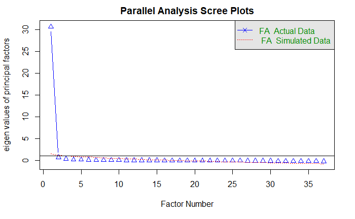

```r
fa.parallel(rho, fa="fa", cor="poly")
```

Parallel analysis suggests one factor.

Very simple structure

```
n.obs was not specified and was arbitrarily set to 1000.  This only affects the chi square values.
```

```
Very Simple Structure
Call: vss(x = rho, cor = "poly")
VSS complexity 1 achieves a maximimum of 1  with  1  factors
VSS complexity 2 achieves a maximimum of 1  with  2  factors

The Velicer MAP achieves a minimum of 0.02  with  4  factors
BIC achieves a minimum of  4434.73  with  8  factors
Sample Size adjusted BIC achieves a minimum of  5698.8  with  8  factors

Statistics by number of factors
```

| vss1 | vss2 | map | dof | chisq | prob | sqresid | fit | RMSEA | BIC | SABIC | complex | eChisq | SRMR | eCRMS | eBIC |
| --- | --- | --- | --- | --- | --- | --- | --- | --- | --- | --- | --- | --- | --- | --- | --- |
| 0.9977057 | 0.0000000 | 0.02634611 | 629 | 14632.761 | 0 | 2.1825666 | 0.9977057 | 0.1492063 | 10287.783 | 12285.522 | 1.000000 | 996.3969 | 0.027350424 | 0.02814335 | -3348.581 |
| 0.4719158 | 0.9985603 | 0.01808506 | 593 | 11754.045 | 0 | 1.3695495 | 0.9985603 | 0.1371872 | 7657.746 | 9541.147 | 1.829268 | 447.5620 | 0.018330508 | 0.01942604 | -3648.737 |
| 0.3653018 | 0.8124622 | 0.01683224 | 558 | 10477.299 | 0 | 1.0821303 | 0.9988624 | 0.1333249 | 6622.771 | 8395.010 | 2.521687 | 296.4180 | 0.014917643 | 0.01629747 | -3558.109 |
| 0.3561663 | 0.7403770 | 0.01675359 | 524 | 9438.945 | 0 | 0.9290209 | 0.9990234 | 0.1304310 | 5819.281 | 7483.534 | 2.907100 | 225.8207 | 0.013020564 | 0.01467916 | -3393.843 |
| 0.3770055 | 0.7641349 | 0.01702295 | 491 | 8664.805 | 0 | 0.8064346 | 0.9991523 | 0.1290204 | 5273.097 | 6832.541 | 3.092462 | 175.2344 | 0.011469847 | 0.01335839 | -3216.473 |
| 0.3718153 | 0.7102080 | 0.01826139 | 459 | 8009.382 | 0 | 0.7186916 | 0.9992445 | 0.1282522 | 4838.722 | 6296.532 | 3.274786 | 140.9494 | 0.010286780 | 0.01239111 | -3029.710 |
| 0.3717141 | 0.7169384 | 0.01930450 | 428 | 7597.871 | 0 | 0.6363013 | 0.9993311 | 0.1294258 | 4641.352 | 6000.704 | 3.337436 | 118.8438 | 0.009445745 | 0.01178288 | -2837.675 |
| 0.3882786 | 0.7116050 | 0.02046356 | 398 | 7184.018 | 0 | 0.5748105 | 0.9993958 | 0.1305730 | 4434.731 | 5698.802 | 3.432403 | 101.1065 | 0.008712392 | 0.01127024 | -2648.180 |

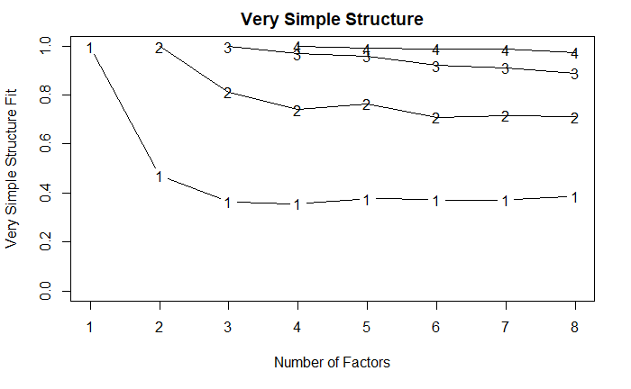

```r
vss(rho, cor="poly")
```

Very simple structure also suggests one, if we assume each variable loads on one factor only.

These tests seem to suggest a single factor is probably the best approach, though it’s possible a two factor approach would be better.

Let’s first fit the 2pl model and examine the output.

```r
m1 <- mirt(Complex_short, 1, itemtype="2PL")
```

[output not shown]

[output cut: 142 more lines]

[output not shown]

```r
m1
```

```
Call:
mirt(data = Complex_short, model = 1, itemtype = "2PL")

Full-information item factor analysis with 1 factor(s).
Converged within 1e-04 tolerance after 197 EM iterations.
mirt version: 1.33.2
M-step optimizer: BFGS
EM acceleration: Ramsay
Number of rectangular quadrature: 61
Latent density type: Gaussian

Log-likelihood = -25839.34
Estimated parameters: 74
AIC = 51826.68; AICc = 51830.77
BIC = 52265.72; SABIC = 52030.6
G2 (1e+10) = 24307.36, p = 1
RMSEA = 0, CFI = NaN, TLI = NaN
```

```r
summary(m1)
```

```
                 F1    h2
morphology761 0.930 0.866
morphology762 0.899 0.808
morphology763 0.904 0.818
morphology764 0.923 0.852
morphology765 0.937 0.879
morphology766 0.881 0.776
morphology767 0.904 0.817
morphology768 0.917 0.840
morphology769 0.915 0.838
morphology770 0.937 0.878
morphology771 0.952 0.906
morphology772 0.927 0.859
syntax773     0.958 0.918
syntax774     0.938 0.879
syntax775     0.948 0.899
syntax776     0.952 0.907
syntax777     0.953 0.908
syntax778     0.942 0.887
syntax779     0.897 0.805
syntax780     0.953 0.908
syntax781     0.933 0.870
syntax782     0.934 0.872
syntax783     0.956 0.913
syntax784     0.949 0.901
syntax785     0.969 0.938
syntax786     0.967 0.934
syntax787     0.960 0.922
syntax788     0.940 0.884
syntax789     0.937 0.878
syntax790     0.969 0.939
syntax791     0.973 0.947
syntax792     0.947 0.896
syntax793     0.966 0.934
syntax794     0.928 0.862
syntax795     0.912 0.832
syntax796     0.967 0.934
syntax797     0.953 0.908

SS loadings:  32.613
Proportion Var:  0.881

Factor correlations:

   F1
F1  1
```

Let’s check the overall fit:

```r
M2(m1)
```

|  | M2 | df | p | RMSEA | RMSEA_5 | RMSEA_95 | SRMSR | TLI | CFI |
| --- | --- | --- | --- | --- | --- | --- | --- | --- | --- |
| stats | 3294.486 | 629 | 0 | 0.0389937 | 0.03767887 | 0.04030537 | 0.06022364 | 0.995046 | 0.9953212 |

RMSEA and CFI are good, SRMSR is a bit high but pretty reasonable.

We can see if individual items misfit – i.e., do the observed cell counts differ from the expected cell counts.

```r
itemfit(m1)
```

| item | S_X2 | df.S_X2 | RMSEA.S_X2 | p.S_X2 |
| --- | --- | --- | --- | --- |
| morphology761 | 29.584 | 24 | 0.009 | 0.199 |
| morphology762 | 45.126 | 28 | 0.015 | 0.021 |
| morphology763 | 35.499 | 27 | 0.011 | 0.127 |
| morphology764 | 38.925 | 26 | 0.013 | 0.050 |
| morphology765 | 27.931 | 32 | 0.000 | 0.673 |
| morphology766 | 33.639 | 34 | 0.000 | 0.485 |
| morphology767 | 28.220 | 30 | 0.000 | 0.559 |
| morphology768 | 31.847 | 25 | 0.010 | 0.162 |
| morphology769 | 38.364 | 28 | 0.012 | 0.092 |
| morphology770 | 34.394 | 32 | 0.005 | 0.354 |

[output cut: 27 more lines]

A few items significantly misfit. Let’s take everything with a p value less than .10. We’ll look at item gam plots of those, which plot the item response probability against the latent variable using a gam function, to look for deviations in the item-response function.

```r
misfit <- itemfit(m1) %>%
  filter(p.S_X2 <= .10) %>%
  select(item) %>%
  as.vector()
```

```r
items_good <- select(Complex_short, -all_of(misfit$item))
items_bad <- select(Complex_short, all_of(misfit$item))
```

```r
mod_fit <- mirt(items_good, 1, "2PL")
```

[output not shown]

[output cut: 195 more lines]

[output not shown]

```r
Theta <- fscores(mod_fit)
```

```r
IG762 <- itemGAM(items_bad$morphology762,Theta)
IG764 <- itemGAM(items_bad$morphology764,Theta)
IG769<- itemGAM(items_bad$morphology769,Theta)
IG771 <- itemGAM(items_bad$morphology771,Theta)

IG783 <- itemGAM(items_bad$syntax783,Theta)
IG792 <- itemGAM(items_bad$syntax792,Theta)
```

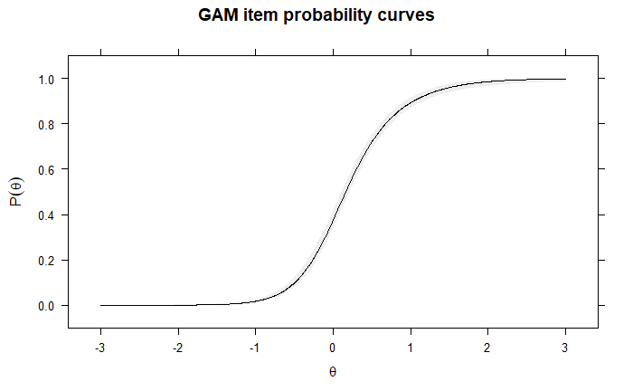

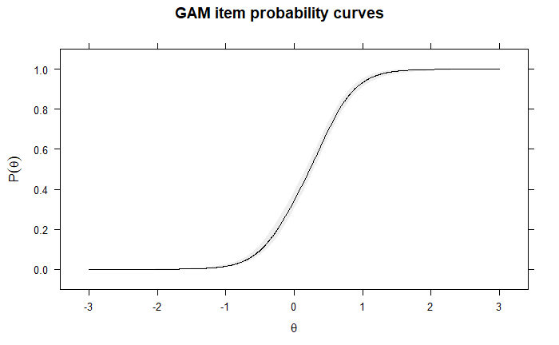

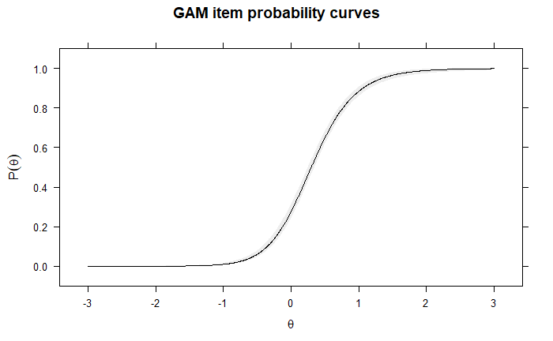

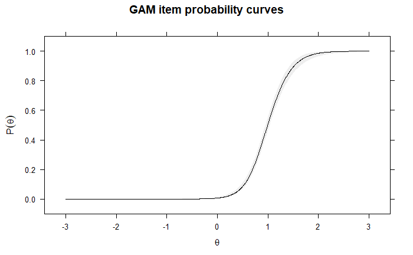

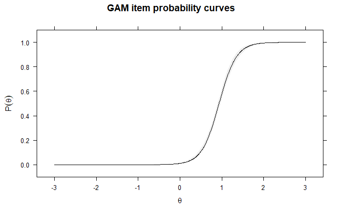

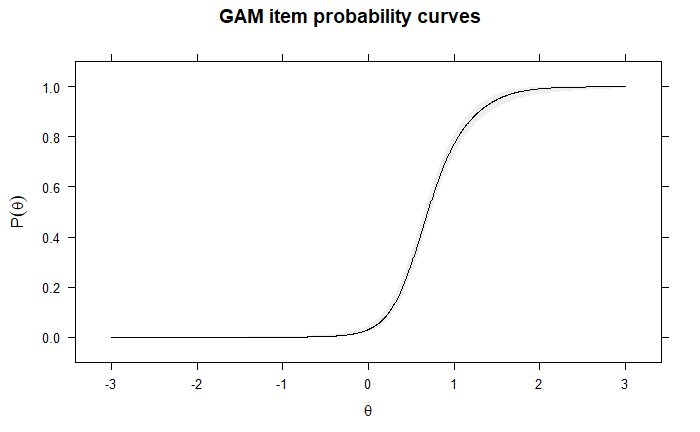

```r
par(mfrow=c(3,2))
plot(IG762); plot(IG764); plot(IG769); plot(IG771); plot(IG783); plot(IG792)
```

These don’t look like massive deviations. They are all monotonic, certainly, but they seem to slow down more than the logistic function. Plot true scores against observed scores.

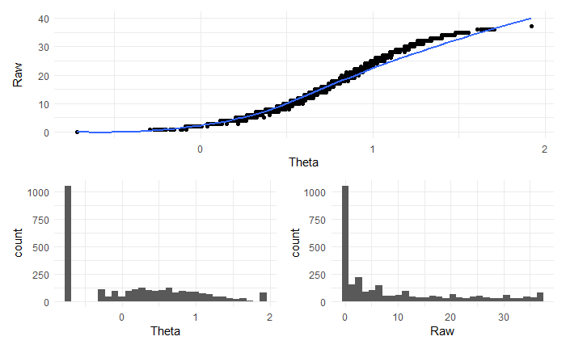

```r
true_raw <- Complex_short %>%
  mutate(
    Raw = rowSums(.[,1:37]),
    Theta = fscores(m1, method="MAP")
  ) %>%
  ggplot(aes(x=Theta, y=Raw)) + geom_point() + stat_smooth(method="loess") + theme_minimal()

raw_score <- Complex_short %>%
  mutate(
    Raw = rowSums(.[,1:37])
    ) %>%
   ggplot(aes(x=Raw)) + geom_histogram() + theme_minimal()

true_score <- Complex_short %>%
  mutate(
    Theta = fscores(m1, method="MAP")
    ) %>%
   ggplot(aes(x=Theta)) + geom_histogram() + theme_minimal()

library(patchwork)

true_raw/(true_score + raw_score)
```

Next let’s take a look at the difficulty and discrimination parameter for each item.

```r
coefs_2pl <- coef(m1, as.data.frame = TRUE) %>%
 t() %>%
  as_tibble() %>%
  select(-c(149:150)) %>%
  pivot_longer(everything()) %>%
  separate(, col=name, into=c("item", "parameter"), sep="([.])") %>%
  pivot_wider(id_cols=item, names_from=parameter, values_from=value) %>%
  select(item, a1, d) %>%
  mutate(
   category =  gsub('[[:digit:]]+', '', item)
  )
```

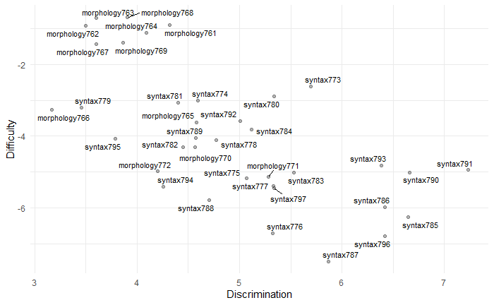

```r
ggplot(coefs_2pl,
       aes(x = a1, y = d)) +
  geom_point(alpha = .3) +
  ggrepel::geom_text_repel(data = coefs_2pl,
                  aes(label = item), size = 3) +
  xlab("Discrimination") +
  ylab("Difficulty") + theme_minimal()
```

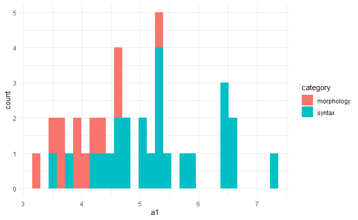

```r
ggplot(coefs_2pl, aes(x=a1, fill=category)) + geom_histogram() + theme_minimal()
```

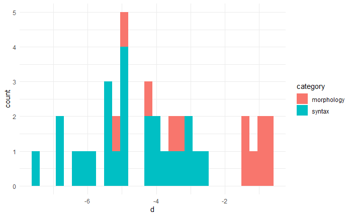

```r
ggplot(coefs_2pl, aes(x=d, fill=category)) + geom_histogram() + theme_minimal()
```

Strong correlation between the difficulty and discrimination parameter. Also note that the morphology items are less difficult than the syntax ones in general.

It’s important to remember that these latent variables are only interpretable if the following conditions hold: 1. The assumption of unidimensionality is appropriate. 2. The assumed distributional form of the latent variable is correct. 3. Measurement invariance holds: the items behave the same way across different groups of participants.

I can test 1 and 2 on my own. 3 is a bit of a stretch for me right now.

Let’s look at the distribution of the latent variable first. MIRT allows us to relax the assumption of normally distributed latent variables at the cost of loss of flexibility. I’ll look at a model which makes no – note to self, check this – assumptions about the form of the latent variable, and compare results to those above.

```r
m1_nonpar <- mirt(Complex_short, 1, itemtype="2PL", dentype = "EH")
```

[output not shown]

[output cut: 363 more lines]

[output not shown]

```r
M2(m1_nonpar)
```

|  | M2 | df | p | RMSEA | RMSEA_5 | RMSEA_95 | SRMSR | TLI | CFI |
| --- | --- | --- | --- | --- | --- | --- | --- | --- | --- |
| stats | 3619.1 | 629 | 0 | 0.04129991 | 0.0399921 | 0.04260353 | 0.218018 | 0.9944427 | 0.9947514 |

```
The following factor score estimates failed to converge successfully:
    1907
```

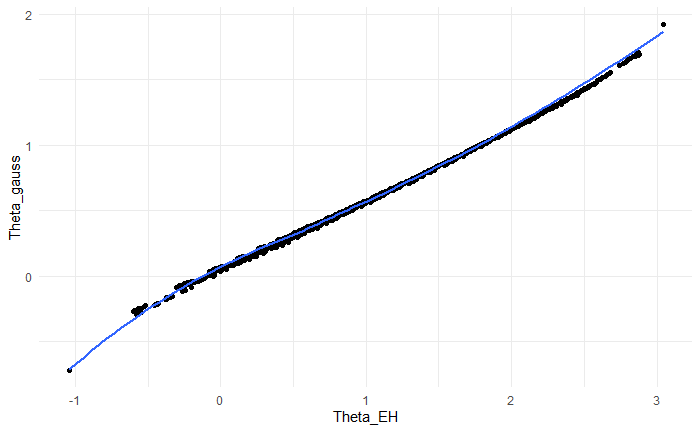

```r
Complex_short %>%
  mutate(
    Theta_EH = fscores(m1_nonpar, method="MAP"),
    Theta_gauss = fscores(m1, method="MAP")
  ) %>%
  ggplot(aes(x=Theta_EH, y=Theta_gauss)) + geom_point() + stat_smooth(method="loess") + theme_minimal()
```

These are quite similar though a bit different in the tails.

```r
m1_nonpar2 <- mirt(Complex_short, 1, itemtype="2PL", dentype = "EHW")
```

[output not shown]

[output cut: 1826 more lines]

[output not shown]

```r
M2(m1_nonpar2)
```

|  | M2 | df | p | RMSEA | RMSEA_5 | RMSEA_95 | SRMSR | TLI | CFI |
| --- | --- | --- | --- | --- | --- | --- | --- | --- | --- |
| stats | 4888.329 | 629 | 0 | 0.04929204 | 0.04800098 | 0.05057514 | 0.1792494 | 0.9920837 | 0.9925235 |

```
The following factor score estimates failed to converge successfully:
    641
```

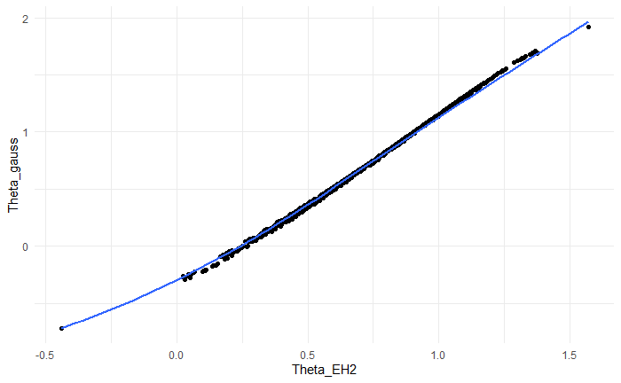

```r
Complex_short %>%
  mutate(
    Theta_EH2 = fscores(m1_nonpar2, method="MAP"),
    Theta_gauss = fscores(m1, method="MAP")
  ) %>%
  ggplot(aes(x=Theta_EH2, y=Theta_gauss)) + geom_point() + stat_smooth(method="loess") + theme_minimal()
```

These are also very, very close. I think it’s sensible to stick with the Gaussian model. It fits better, its simpler and more flexible, and the factor scores are really, really similar across the two approaches.

The next thing we can do is check the dimensionality. I got mixed results before. Check dimensionality against 2 dimensional model.

Formal test of dimensionality. We need to fit the moel with ltm

```r
m1_ltm <- ltm(Complex_short ~z1)
```

```r
unidimTest(m1_ltm, Complex_short)
```

[output not shown]

```r
m2 <- mirt(Complex_short, 2, itemtype="2PL")
```

```r
summary(m2, "oblimin", suppress=.10)
```

[output not shown]

```r
anova(m1, m2)
```

[output not shown]

```r
M2(m2)
```

[output not shown]

```r
itemfit(m2)
```

[output not shown]

```r
model.1 <- mirt.model('
                      F1 = 1 - 12
                      F2 = 13 - 37
                      COV=F1*F2')

m3 <- mirt(Complex_short, model.1, "2PL")
```

```r
M2(m3)
```

[output not shown]

```r
summary(m3)
```

[output not shown]

```r
anova(m1, m3)
```

[output not shown]

```r
anova(m2, m3)
```

[output not shown]

```r
m3 <- mirt(Complex_short, 1, itemtype="3PLu")
```

```r
M2(m3)
```

[output not shown]

```r
anova(m1, m3)
```

[output not shown]

```r
Complex_short %>%
  mutate(
    Raw = rowSums(.[,1:37]),
    Theta = fscores(m3, method="MAP")
  ) %>%
  ggplot(aes(x=Theta, y=Raw)) + geom_point() + stat_smooth(method="loess")
```

[output not shown]

```r
m4 <- mirt(Complex_short, 1, itemtype="2PL", dentype="EHW")
```

```r
M2(m4)
```

[output not shown]

```r
Complex_short %>%
  mutate(
    Raw = rowSums(.[,1:37]),
    Theta = fscores(m3, method="MAP")
  ) %>%
  ggplot(aes(x=Theta, y=Raw)) + geom_point() + stat_smooth(method="loess")
```

[output not shown]